# Testing-estimators-with-EstimDiagnostics

```r
library(EstimDiagnostics)
library(doParallel)
```

```r
library(ggplot2)

registerDoSEQ()
s<-c(1e1,1e2,1e3)
Nmc=6e2
```

## Diagnostic functions

The main function is `Estim_diagnost` which takes the simulation and estimation procedure `Inference` with a sample size as an argument. `Inference` can return a named vector, a list or a data frame. `Estim_diagnost` returns a data frame.

```r
Inference<-function(s){
  rrr<-rnorm(n=s)
  list(Mn=mean(rrr), Var=var(rrr))
}

experiment <- Estim_diagnost(Nmc, s=s, Inference)
head(experiment)
```

```
#>           Mn       Var  s
#> 1  0.1418157 0.4292025 10
#> 2  0.3447723 0.8160422 10
#> 3 -0.7148383 1.2921048 10
#> 4 -0.3415064 1.0301130 10
#> 5  0.1572961 0.9296052 10
#> 6  0.1819580 1.3757514 10
```

This data frame consists of columns with estimates (`Mn` and `Var` in this case) and a sample size `s` at which estimates were evaluated.

There are two plot functions that can visualize the results of the simulation study- `estims_qqplot` and `estims_boxplot`. The following line plots both estimators from experiment against standard normal distribution. It is known that empirical variance in this case is distributed according to chi-square law. As expected, we see that the distribution of variance converges to a Gaussian law but at small sample sizes notably differs from it.

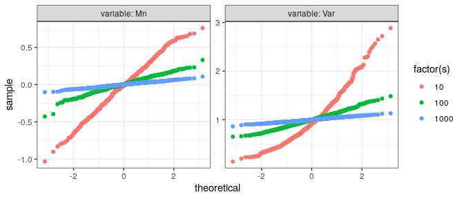

```r
estims_qqplot(experiment)
```

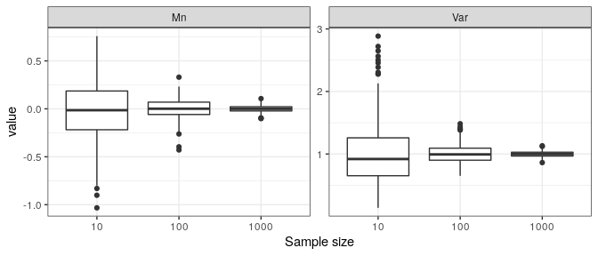

```r
estims_boxplot(experiment)
```

Each plot has argument `sep` allowing to switch between plotting different estimators together or separately. If `sep=TRUE` then the functions return a list of ggplot objects that can be treated and then plotted independently. Here for each plot we set custom distributions qq-plots will be based on:

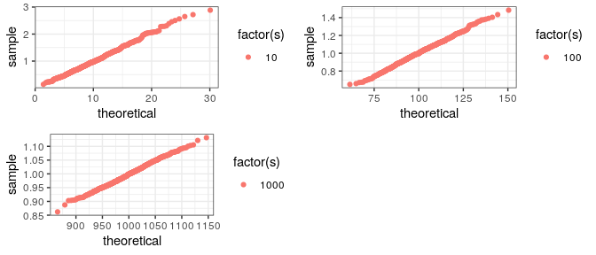

```r
library(gridExtra)

dist1 <- function(p) stats::qchisq(p, df=1e1)
p1<-estims_qqplot(experiment[experiment$s==1e1,], sep=TRUE, distribution = dist1)

dist2 <- function(p) stats::qchisq(p, df=1e2)
p2<-estims_qqplot(experiment[experiment$s==1e2,], sep=TRUE, distribution = dist2)

dist3 <- function(p) stats::qchisq(p, df=1e3)
p3<-estims_qqplot(experiment[experiment$s==1e3,], sep=TRUE, distribution = dist3)

grid.arrange(arrangeGrob(p1[[2]], p2[[2]], p3[[2]], ncol=2))
```

## Unit tests

Once it is shown by means of exploratory analysis that the estimators of interest follow some theoretical distribution, it is desirable to write unit tests for them. This package provides the following `expect_` type functions as an extension of testthat package:

- `expect_distfit`
- `expect_gaussian`
- `expect_mean_equal`

In order to test correctness of the mu estimator, `expect_mean_equal` is called. It uses t-test to test the hypothesis that the empirical mean is different from a chosen value.

```r
s <- 1e1
set.seed(1)

experiment <- Estim_diagnost(Nmc, s=s, Inference)

sam_m <- experiment[,1]
expect_mean_equal(x=sam_m, mu=0)
```

For variance estimator we make a unit test based on the fact that the empirical variance follows a chi-square distribution. Tests for matching empirical distributions to parametric ones are implemented in `expect_distfit` function.

```r
sam_v <- experiment[,2]*10
expect_distfit(sample = sam_v, nulldist=pchisq, df=10)
```